# Graph Mining Project par Fatma Zahra Zakhama

# Book Recommendation System

# M2 Big Data & AI

## *GNN : Graph Neural Network*

Un réseau de neurones graphique (GNN) est un type de modèle d'apprentissage automatique qui peut être utilisé pour traiter des données structurées sous forme de graphes. Les graphes sont des structures de données qui représentent des relations entre des objets ou des concepts, où les objets sont représentés par des nœuds et les relations par des arêtes. Les GNN sont conçus pour traiter ces données en utilisant des mécanismes d'agrégation de voisinage pour combiner les informations des nœuds voisins d'un nœud donné. Les GNN peuvent être utilisés pour des tâches telles que la classification de nœuds, la prédiction de lien ou la génération de graphes. Les GNNs sont particulièrement utiles pour les tâches de traitement de données liées aux graphes comme les systèmes de recommandations, la reconnaissance de la communauté, l'analyse de la propagation de l'information dans les réseaux sociaux.

## *Un Système de recommandation*

Un système de recommandation est un système qui cherche à prédire ou à filtrer les préférences en fonction des choix de l'utilisateur. Les systèmes de recommandation sont utilisés dans une variété de domaines, tels que les films, la musique, les nouvelles, les livres, les articles de recherche, les requêtes de recherche, les tags sociaux et les produits en général. Ils permettent de développer les idées en fournissant des suggestions personnalisées en fonction des préférences de l'utilisateur. Les systèmes de recommandation basés sur les réseaux de neurones graphiques (GNN) permettent de modéliser les relations entre les utilisateurs et les éléments (comme les livres) qu'ils ont consommé, et d'utiliser ces relations pour prédire les éléments que l'utilisateur aimera dans l'avenir.

## *Domaine : Un Système de recommandation pour les livres*

- **Un réseau neuronal de graphe (GNN)** est un type de modèle d'apprentissage profond qui peut être utilisé pour **les systèmes de recommandation** de livres. Les GNN sont particulièrement adaptés à cette tâche car ils peuvent modéliser efficacement les relations entre les livres et les utilisateurs dans un système de recommandation.
- Dans un système de recommandation de livres utilisant des GNN, les livres et les utilisateurs peuvent être représentés comme des nœuds dans un graphe , avec des arêtes représentant les relations entre eux qui sera représenté avec les notes(ratings) que contribuera chaque utilisateur aux livres (par exemple, l'utilisateur A a lu le livre X et l'a noté 7). Le GNN peut alors être entraîné pour apprendre la structure du graphe et faire des prévisions sur les livres qui pourraient intéresser un utilisateur en fonction de son historique de lecture et des relations entre les livres qu'il a lus et les autres livres dans le graphe en utilisant cette information pour faire des recommandations personnalisées aux utilisateurs.

> L'un des principaux avantages des GNN est qu'ils peuvent prendre en compte les relations entre différents livres et utilisateurs, ce qui peut être plus efficace que les approches de **filtrage collaboratif traditionnelles** basées uniquement sur les interactions utilisateur-élément.

## *Machine Learning pour les graphs*

Les étapes pour l'application de l'apprentissage automatique (Machine Learning) sur les graphes peuvent varier en fonction de la tâche spécifique et de la technique utilisée. Cependant, voici les étapes générales courantes :

1. Préparation des données : Il s'agit de préparer les données pour l'analyse en utilisant une technique appropriée. Cela peut inclure la transformation de données brutes en un format utilisable, la création de sous-graphes pour une analyse plus ciblée ou la conversion de données non-structurées en graphes.
2. Représentation des données : Il s'agit de représenter les données sous forme de graphe. Cela peut inclure la définition des noeuds et des arêtes, la définition des caractéristiques des noeuds et des arêtes, et la définition des poids des arêtes. Il est possible de visualiser cela en utilisant des schémas pour décrire les différentes étapes.
3. Embedding de graphe : Pour certaines tâches, il peut être nécessaire de convertir les noeuds du graphe en vecteurs de dimension réduite pour pouvoir utiliser des modèles d'apprentissage automatique standard. Pour cela, il faut choisir une méthode pour calculer les poids des arêtes du graphe, utiliser ces poids pour construire une matrice de similarité entre les nœuds du graphe, et Appliquer une technique de décomposition de matrice pour obtenir des vecteurs d'embedding pour chaque nœud.
4. Entraînement : Il s'agit de construire et d'entraîner un modèle d'apprentissage automatique en utilisant les données représentées sous forme de graphe. Cela peut inclure l'utilisation de techniques d'apprentissage supervisé, non supervisé ou renforcé.
5. Évaluation : Il s'agit d'évaluer les résultats obtenus en utilisant des métriques appropriées. Il est important de comparer les résultats obtenus avec des résultats attendus ou des résultats obtenus avec d'autres méthodes.

## *Graphe biparti*

Un système de recommandation utilise souvent un graphe biparti pour modéliser les relations entre les utilisateurs et les éléments qu'ils ont consommés ou notés. Un graphe biparti est un type de graphe dans lequel les nœuds sont divisés en deux groupes distincts, appelés **ensembles de nœuds**, et **les arêtes ne relient que les nœuds d'ensembles différents**. Dans notre cas :

- l'un des ensembles de nœuds va représenter les utilisateurs, tandis que l'autre ensemble de nœuds peut représenter les éléments recommandés qui sont les livres.
- Les arêtes du graphe indiquent les relations entre les utilisateurs et les livres,qui sera la note attribués d'aprés l'utilisateur pour les livres qu'il a lu.

> Les GNN sont utilisés pour explorer les propriétés des graphes bipartis et pour prédire les relations entre les utilisateurs et les éléments.
- Voici une présentation de l'architecture de notre graphe bipartie :

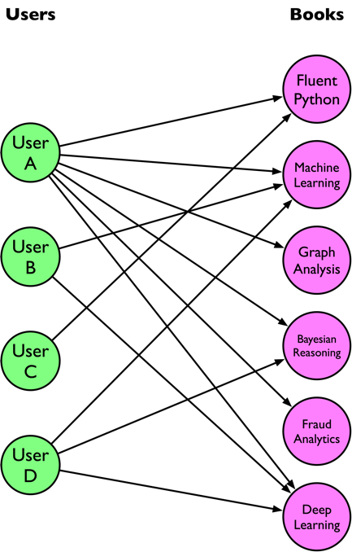

> Aprés avoir choisi notre architecture de notre graphe , nous devons choisir le modèle GNN adéquat qui est **LightGCN** qui a pour but d'améliorer les modèles conventionnels de filtrage collaboratif modèles (exp : factorisation de la matrice) en modélisant explicitement la structure des graphes à l'aide des GNN..

## *LightGCN*

- **LightGCN** est une version allégée des réseaux de convolution sur les graphes (GCN), un type de modèle d'apprentissage profond pour les données structurées en graphe. LightGCN est conçu pour être plus efficace et plus rapide que les modèles GCN traditionnels, tout en conservant des performances similaires ou meilleures.
- **L'idée principale derrière LightGCN** est de simplifier l'architecture GCN et de réduire le nombre de paramètres en remplaçant la multiplication de matrice de poids pleine par une multiplication de matrice creuse. Cela permet au modèle d'apprendre une représentation compacte et plus efficace de la structure du graphe.
- Le bloc de construction de base de LightGCN est la couche LightGCN, qui est une version simplifiée de la couche GCN. Chaque couche LightGCN possède une matrice de poids creuse qui est utilisée pour calculer les caractéristiques de sortie de la couche. La matrice de poids creuse est obtenue en utilisant une étape de prétraitement qui sélectionne un sous-ensemble des arêtes les plus importantes dans le graphe.Il utilise également une stratégie de normalisation différente appelée **normalisation de graphe par arête** , qui au lieu d'utiliser la matrice de degré comme facteur de normalisation, utilise la matrice identité plus la matrice d'adjacence normalisée par arête.

Voici l'architecture du Light GCN :

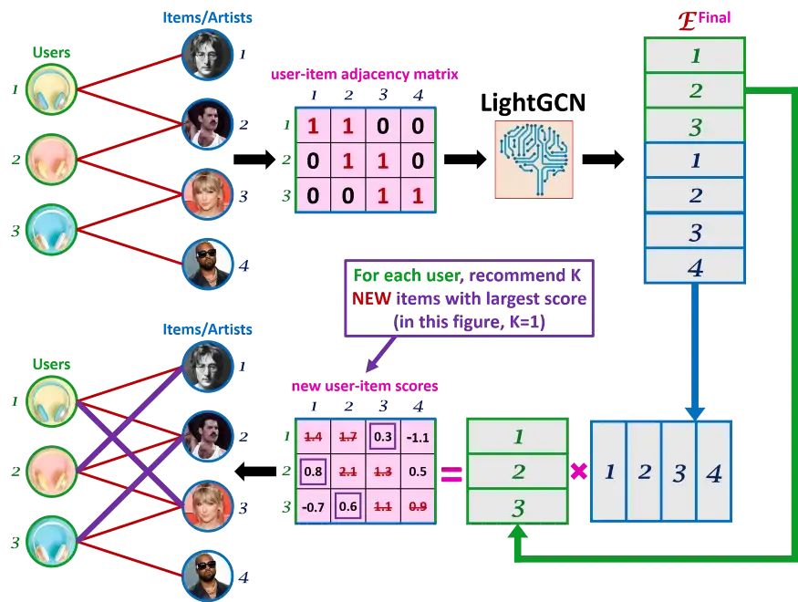

Entre chaque couche, le LightGCN utilise la règle de propagation suivante pour l'intégration des utilisateurs et des éléments.

\begin{equation} e_u^{(k+1)} = \sum_{i \in N_u} \frac{1}{\sqrt{|N_u|}\sqrt{|N_i|}} e_i^{(k)} \quad e_i^{(k+1)} = \sum_{u \in N_i} \frac{1}{\sqrt{|N_i|}\sqrt{|N_u|}} e_u^{(k)} \end{equation}

$N_u$ : l'ensemble de tous les voisins de l'utilisateur $u$ (éléments aimés par $u$)

$N_i$ : l'ensemble de tous les voisins de l'élément $i$ (utilisateurs qui ont aimé $i$)

$e_u^{(k)}$ : intégration de l'utilisateur de la k-ième couche

$e_i^{(k)}$ : intégration de l'élément de la k-ième couche

## Combinaison de couches et prédiction du modèle

Les seuls paramètres entraînables du LightGCN sont les embeddings de la couche 0, $e_u^{(0)}$ et $e_i^{(0)}$ pour chaque utilisateur et chaque élément. Nous combinons les incorporations obtenues à chaque couche de propagation pour former les incorporations finales pour tous les utilisateurs et éléments, $e_u$ et $e_i$ via l'équation suivante.

\begin{equation} e_u = \sum_{k = 0}^K \alpha_k e_u^{(k)} \quad e_i = \sum_{k = 0}^K \alpha_k e_i^{(k)} \end{equation}

$\alpha_k$ : hyperparamètre qui pondère la contribution de l'incorporation de la k-ième couche à l'incorporation finale.

La prédiction du modèle est obtenue en prenant le produit interne des encastrements finaux de l'utilisateur et de l'élément.

\begin{equation} \hat{y}_{ui} = e_u^Te_i \end{equation}

## Forme matricielle

Dans notre implémentation, nous utilisons la forme matricielle du LightGCN. Nous effectuons une diffusion multi-échelle pour obtenir l'incorporation finale, qui additionne les incorporations diffusées à travers les échelles multi-sauts.

\begin{equation} E^{(K)} = \alpha_0 E^{(0)} + \alpha_1 \tilde{A}^1 E^{(0)} + \alpha_2 \tilde{A}^2 E^{(0)} + \cdot \cdot \cdot + \alpha_K \tilde{A}^K \tilde{A} E^{(0)} \end{equation}

$E^{(0)} \in \mathcal{R}^{(M + N)} \times T$ : Embeddings initiaux empilés d'éléments et d'utilisateurs où $M$, $N$ et $T$ désignent respectivement le nombre d'utilisateurs, le nombre d'éléments et la dimension de chaque embedding

$\tilde{A} = D^{-\frac{1}{2}}AD^{-\frac{1}{2}}$ :Matrice d'adjacence symétriquement normalisée

# Métriques d'évaluation

Nous évaluons notre modèle à l'aide des métriques suivantes

\begin{equation} \text{Recall} = \frac{TP}{TP + FP} \end{equation}\begin{equation} \text{Précision} = \frac{TP}{TP + FN} \end{equation}

Le rappel@k et la précision@k s'appliquent uniquement aux K premiers éléments recommandés, puis, pour l'ensemble des éléments recommandés, le rappel@k et la précision@k s'appliquent à l'ensemble des éléments recommandés. Recall@k et Precision@k, la moyenne est calculée en fonction du nombre d'utilisateurs.

## *Description des ensembles de données*

Nous allons utiliser une Dataset de systeme de recommandation pour les livres de la platforme kaggle : [Book Recommendation Dataset](https://www.kaggle.com/datasets/arashnic/book-recommendation-dataset) . Notre jeu de données comprend 3 tables :

1. **Table Livres:**

Les livres sont identifiés par leur **ISBN** respectif. Les ISBN non valides ont déjà été supprimés de l'ensemble de données. En outre, certaines informations basées sur le contenu sont fournies (titre du livre, auteur du livre, année de publication, éditeur), obtenues auprès d'Amazon Web Services. Notez que dans le cas de plusieurs auteurs, seul le premier est fourni. Les URL qui renvoient aux images de couverture sont également indiquées. Elles se présentent sous trois formes différentes (Image-URL-S, Image-URL-M, Image-URL-L), à savoir petite, moyenne et grande. Ces URL renvoient au site Web d'Amazon.

1. **Table Users :**

Contient les utilisateurs.Les identifiants des utilisateurs (**User-ID)** ont été rendus anonymes et sont convertis en nombres entiers. Les données démographiques sont fournies (localisation, âge) si elles sont disponibles. Sinon, ces champs contiennent des valeurs NULL.

1. **Table Ratings :**

Contient les informations relatives à la notation du livre. Les notations **(Book-Rating)** sont soit explicites, exprimées sur une échelle de 1 à 10 (les valeurs les plus élevées dénotant une plus grande appréciation), soit implicites, exprimées par 0.

> Nous allons se focaliser sur la table Raitings car elle nous intèresse pour faire les recommendation des livres .

## **Importation des Bibliothèques**

```python
! pip install -q torch-scatter -f https://pytorch-geometric.com/whl/torch-1.13.0+cu116.html
! pip install -q torch-sparse -f https://pytorch-geometric.com/whl/torch-1.13.0+cu116.html
! pip install -q torch-geometric
```

```python
import torch
print(torch.__version__)
```

```
1.13.1+cu116
```

```python
!pip install -q torch-scatter -f https://data.pyg.org/whl/torch-1.10.0+cu113.html
```

```python
!pip install -q torch-sparse -f https://data.pyg.org/whl/torch-1.10.0+cu113.html
```

```python
import numpy as np
import pandas as pd
import networkx as nx
import matplotlib.pyplot as plt
from networkx.algorithms import bipartite
from networkx.drawing.layout import bipartite_layout

from sklearn import model_selection, metrics, preprocessing

import numpy as np
import pandas as pd
import re
import matplotlib.pyplot as plt
import seaborn as sns
import plotly.express as px
# import required modules
import random
from tqdm.notebook import tqdm
import pandas as pd
import numpy as np
import matplotlib.pyplot as plt
from sklearn.model_selection import train_test_split
from sklearn import model_selection, metrics, preprocessing
import copy
from torch_geometric.utils import degree

import torch
from torch import nn, optim, Tensor

from torch_sparse import SparseTensor, matmul

from torch_geometric.utils import structured_negative_sampling
from torch_geometric.data import download_url, extract_zip
from torch_geometric.nn.conv.gcn_conv import gcn_norm
from torch_geometric.nn.conv import MessagePassing
from torch_geometric.typing import Adj
from torch_geometric.data import Dataset, Data
```